# Project: College Dataset

# Now we can plot the residuals: YES?

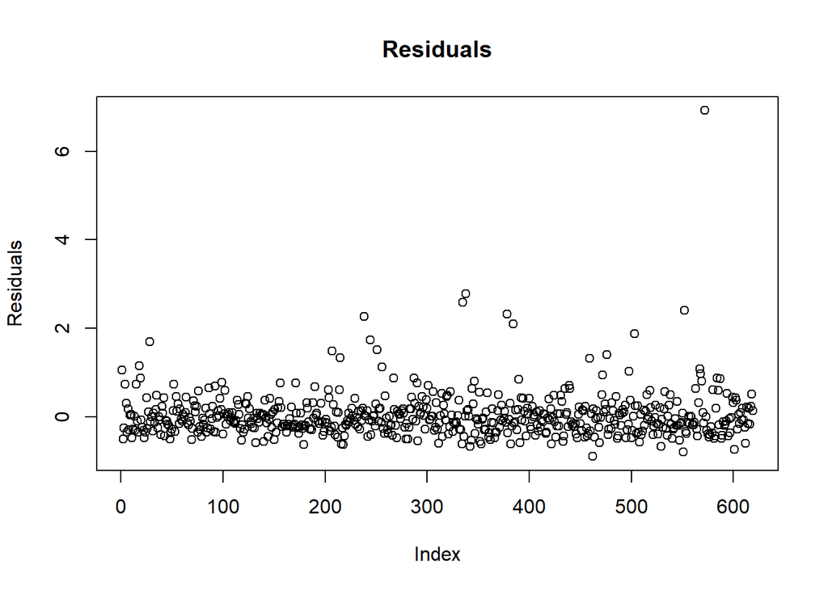

```r
# Plot the residuals
plot(glm$residuals, main="Residuals", ylab="Residuals")
```

We will try to fit a random forest model on the training set and see if it performs better than the glm:

```r
library(randomForest)
library(randomForestExplainer)

random_forest <- randomForest(x=train_data, formula=Apps ~ ., y=College$Apps[train_index], data = train_data,  ntree = 100, nodesize=1, xtest=test_data, ytest=College$Apps[-train_index], keep.forest = TRUE, replace = TRUE, proximity=TRUE, oob.prox = FALSE, importance = TRUE, localImp = TRUE)

random_forest
```

```
##
## Call:
##  randomForest(x = train_data, y = College$Apps[train_index], xtest = test_data,      ytest = College$Apps[-train_index], ntree = 100, replace = TRUE,      nodesize = 1, importance = TRUE, localImp = TRUE, proximity = TRUE,      oob.prox = FALSE, keep.forest = TRUE, formula = Apps ~ .,      data =…
##                Type of random forest: regression
##                      Number of trees: 100
## No. of variables tried at each split: 4
##
##           Mean of squared residuals: 3851069
##                     % Var explained: 76.05
##                        Test set MSE: 1992994
##                     % Var explained: 81.22
```

Now we can calculate the RMSE for the random forest model:

```r
#RMSE train_set
rf_rmse_train_set <- sqrt(random_forest$mse[length(random_forest$mse)])

#RMSE test_set
rf_rmse_test_set <- sqrt(random_forest$test$mse[length(random_forest$test$mse)])
```

The rmse for the train_set is inside `rf_rmse_train_set`:

```r
rf_rmse_train_set
```

```
## [1] 1962.414
```

The rmse for the test_set is inside `rf_rmse_test_set`:

```r
rf_rmse_test_set
```

```
## [1] 1411.734
```

The RMSE of the random forest model is lower than the RMSE of the glm model, which means that the random forest model is performing better than the glm model.

Now we can plot how the MSE of the model changes with the number of trees:

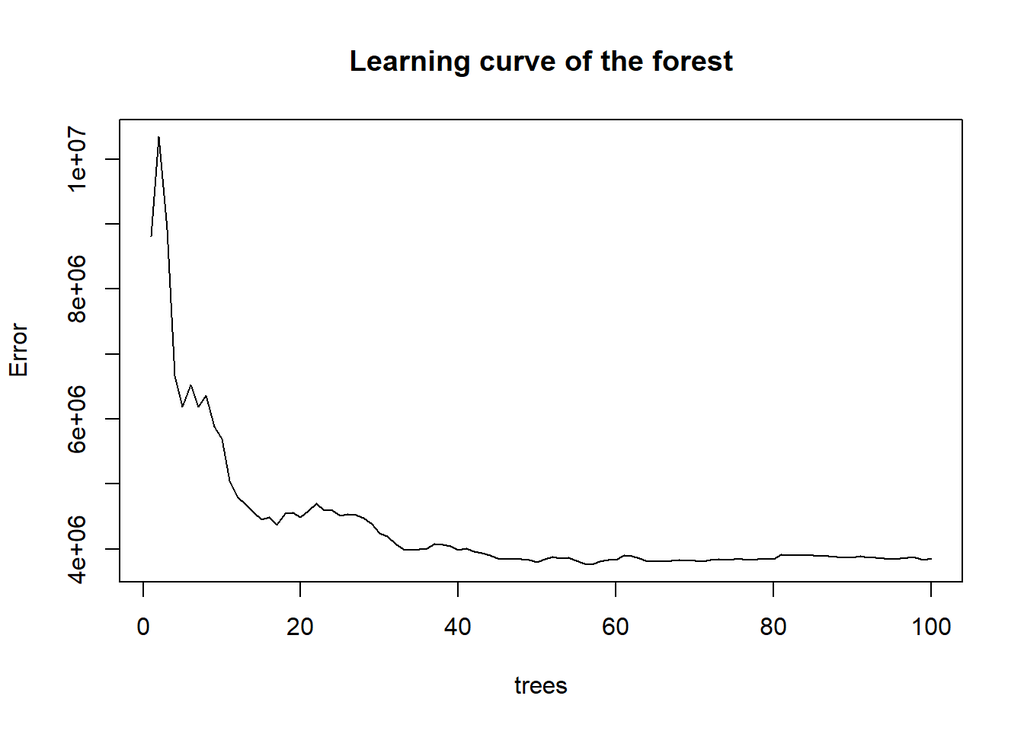

```r
plot(random_forest, main = "Learning curve of the forest")
```

Now explore how the variables are used in the random forest:

```r
measure_importance(random_forest)
```

| variable | mean_min_depth | no_of_nodes | mse_increase | node_purity_increase | no_of_trees | times_a_root | p_value |
| --- | --- | --- | --- | --- | --- | --- | --- |
| Books | 3.7400 | 2532 | -270617.3 | 234728137 | 100 | 3 | 1.000000e+00 |
| Expend | 2.3900 | 3320 | 968186.6 | 595865266 | 100 | 5 | 3.420597e-09 |
| F.Undergrad | 1.1600 | 4435 | 13947069.3 | 3853122354 | 100 | 30 | 1.329068e-142 |
| Grad.Rate | 2.7700 | 3183 | 2870676.7 | 620419170 | 100 | 0 | 5.648074e-04 |
| Outstate | 2.6800 | 3502 | 1364694.6 | 494687655 | 100 | 1 | 3.814932e-20 |
| P.Undergrad | 2.1800 | 3264 | 2763740.6 | 1111092839 | 100 | 21 | 9.631230e-07 |
| perc.alumni | 3.9300 | 2928 | 147399.1 | 189797185 | 100 | 0 | 9.406634e-01 |
| Personal | 3.8400 | 3014 | 186349.0 | 202430936 | 100 | 2 | 4.689851e-01 |
| Private | 4.2166 | 239 | 3283327.3 | 562522412 | 98 | 19 | 1.000000e+00 |
| Room.Board | 3.2100 | 3379 | 460229.4 | 283365283 | 100 | 0 | 3.031443e-12 |

[output cut: 3 more lines]

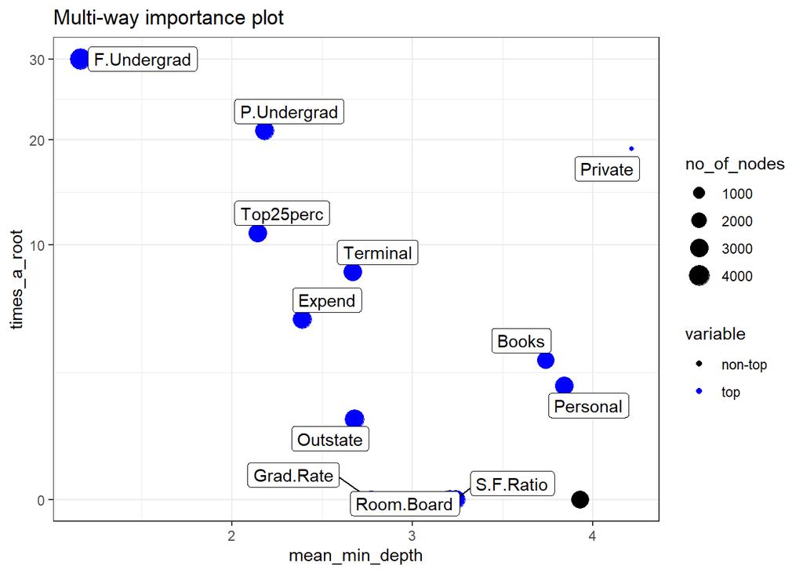

```r
plot_multi_way_importance(measure_importance(random_forest), size_measure = "no_of_nodes")
```

And if we increse the number of trees from 100 to 1000:

```r
random_forest_1000 <- randomForest(x=train_data, formula=Apps ~ ., y=College$Apps[train_index], data = train_data,  ntree = 1000, nodesize=1, xtest=test_data, ytest=College$Apps[-train_index], keep.forest = TRUE, replace = TRUE, proximity=TRUE, oob.prox = FALSE, importance = TRUE, localImp = TRUE)

random_forest_1000
```

```
##
## Call:
##  randomForest(x = train_data, y = College$Apps[train_index], xtest = test_data,      ytest = College$Apps[-train_index], ntree = 1000, replace = TRUE,      nodesize = 1, importance = TRUE, localImp = TRUE, proximity = TRUE,      oob.prox = FALSE, keep.forest = TRUE, formula = Apps ~ .,      data …
##                Type of random forest: regression
##                      Number of trees: 1000
## No. of variables tried at each split: 4
##
##           Mean of squared residuals: 3766066
##                     % Var explained: 76.58
##                        Test set MSE: 1739743
##                     % Var explained: 83.61
```

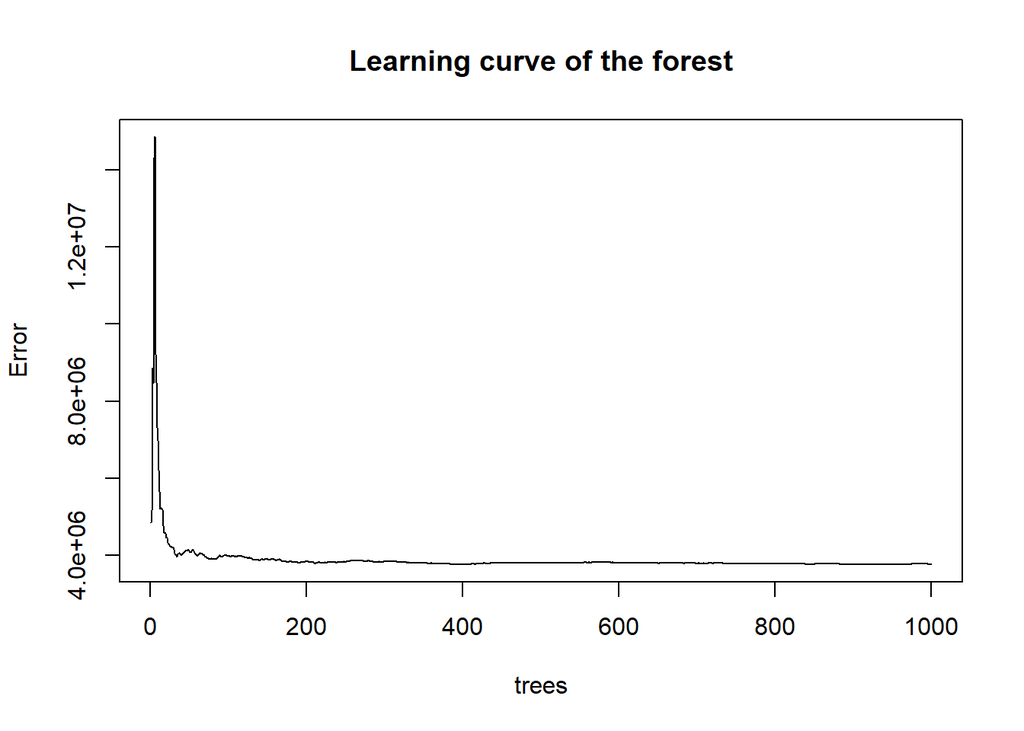

```r
plot(random_forest_1000, main = "Learning curve of the forest")
```

```r
#RMSE train_set
rf_rmse_train_set_1000 <- sqrt(random_forest_1000$mse[length(random_forest_1000$mse)])

#RMSE test_set
rf_rmse_test_set_1000 <- sqrt(random_forest_1000$test$mse[length(random_forest_1000$test$mse)])
```

Analyze Root Mean Square Error for the random forest model with 1000 trees:

```r
rf_rmse_train_set_1000
```

```
## [1] 1940.636
```

```r
rf_rmse_test_set_1000
```

```
## [1] 1318.993
```

And now how the variables are used:

```r
measure_importance(random_forest_1000)
```

| variable | mean_min_depth | no_of_nodes | mse_increase | node_purity_increase | no_of_trees | times_a_root | p_value |
| --- | --- | --- | --- | --- | --- | --- | --- |
| Books | 3.810000 | 26124 | -284787.6 | 216087814 | 1000 | 23 | 1.000000e+00 |
| Expend | 2.637000 | 32560 | 1488675.2 | 609119959 | 1000 | 34 | 5.919533e-50 |
| F.Undergrad | 1.109000 | 44222 | 14523211.1 | 4071999455 | 1000 | 318 | 0.000000e+00 |
| Grad.Rate | 2.764000 | 32034 | 2542016.0 | 632232768 | 1000 | 1 | 4.736208e-32 |
| Outstate | 2.649000 | 34433 | 1134720.0 | 510531554 | 1000 | 3 | 7.051360e-146 |
| P.Undergrad | 2.299000 | 32837 | 2908005.4 | 1016501435 | 1000 | 205 | 5.373963e-61 |
| perc.alumni | 3.875000 | 29181 | 466011.7 | 170546344 | 1000 | 0 | 9.999999e-01 |
| Personal | 3.709000 | 29640 | 50507.9 | 232546946 | 1000 | 7 | 9.943987e-01 |
| Private | 4.391852 | 2631 | 2316475.1 | 482882387 | 981 | 162 | 1.000000e+00 |
| Room.Board | 3.121000 | 33188 | 472246.6 | 342252760 | 1000 | 7 | 1.426028e-76 |

[output cut: 3 more lines]

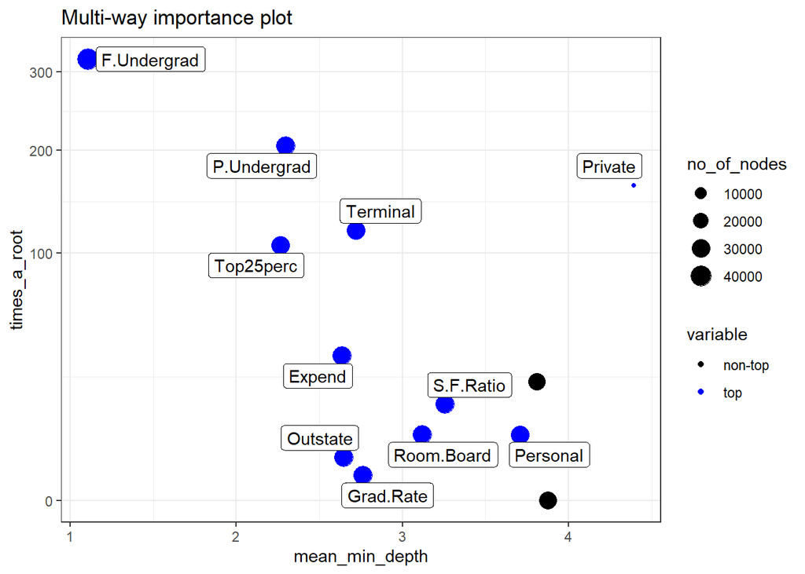

```r
plot_multi_way_importance(measure_importance(random_forest_1000), size_measure = "no_of_nodes")
```

From the graph we can see that there are a number of threes that have better performance:

##### Lets go back to the results for the glm model

```r
summary(glm)
```

```
##
## Call:
## glm(formula = College$Apps[train_index] ~ ., family = poisson,
##     data = train_data)
##
## Coefficients:
##              Estimate Std. Error z value Pr(>|z|)
## (Intercept)  4.092305   0.008438 485.009  < 2e-16 ***
## Private     -0.184864   0.002964 -62.360  < 2e-16 ***
## Top25perc    0.177462   0.004820  36.818  < 2e-16 ***
## F.Undergrad  4.729292   0.007555 625.964  < 2e-16 ***
## P.Undergrad -0.146204   0.007927 -18.443  < 2e-16 ***
## Outstate     0.492628   0.007140  68.997  < 2e-16 ***
## Room.Board   0.748332   0.006285 119.061  < 2e-16 ***
## Books        0.282714   0.010330  27.368  < 2e-16 ***
## Personal    -0.350038   0.008107 -43.179  < 2e-16 ***
## Terminal     0.019375   0.006914   2.802  0.00508 **
## S.F.Ratio    0.351358   0.009843  35.696  < 2e-16 ***
## perc.alumni -0.049954   0.005894  -8.475  < 2e-16 ***
## Expend       0.570555   0.010381  54.959  < 2e-16 ***
## Grad.Rate    0.955605   0.006981 136.879  < 2e-16 ***
## ---
## Signif. codes:  0 '***' 0.001 '**' 0.01 '*' 0.05 '.' 0.1 ' ' 1
##
## (Dispersion parameter for poisson family taken to be 1)
##
##     Null deviance: 2120079  on 618  degrees of freedom
## Residual deviance:  221113  on 605  degrees of freedom
## AIC: 226872
##
## Number of Fisher Scoring iterations: 4
```

##### There are a couple of takeaways here. First of all the the residual deviance is much lower than the null deviance, so the glm model explains a lot of variance. However the residual deviance od 221,113 is still quite large. Compared to the degrees of freedom this could be due to potential model misspecification, which could be due to non-linearity.

##### Now when we look at back at the multi way importance plot we see that the F.Undergrad and P.Undergrad are the most important features. Lets see the partial dependence plot for these two features.

```r
library(pdp)

names <- colnames(train_data)

names <- names[-1]

names
```

```
##  [1] "Top25perc"   "F.Undergrad" "P.Undergrad" "Outstate"    "Room.Board"
##  [6] "Books"       "Personal"    "Terminal"    "S.F.Ratio"   "perc.alumni"
## [11] "Expend"      "Grad.Rate"
```

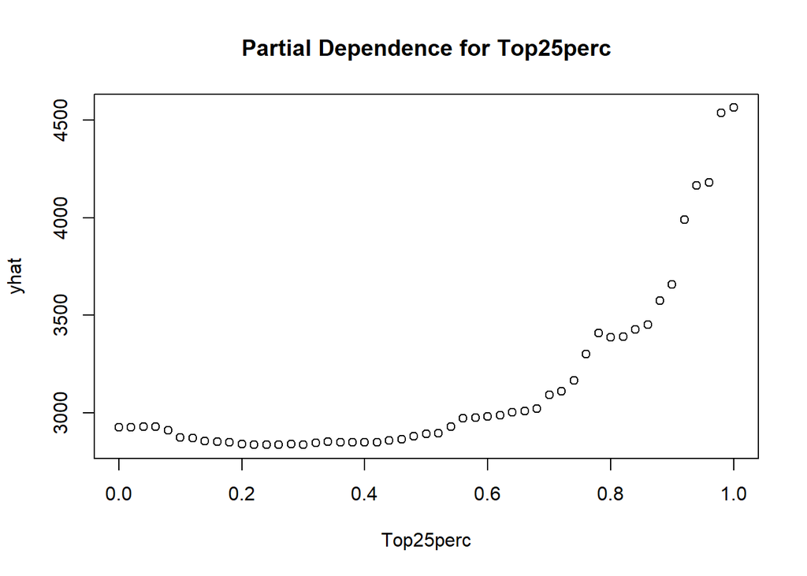

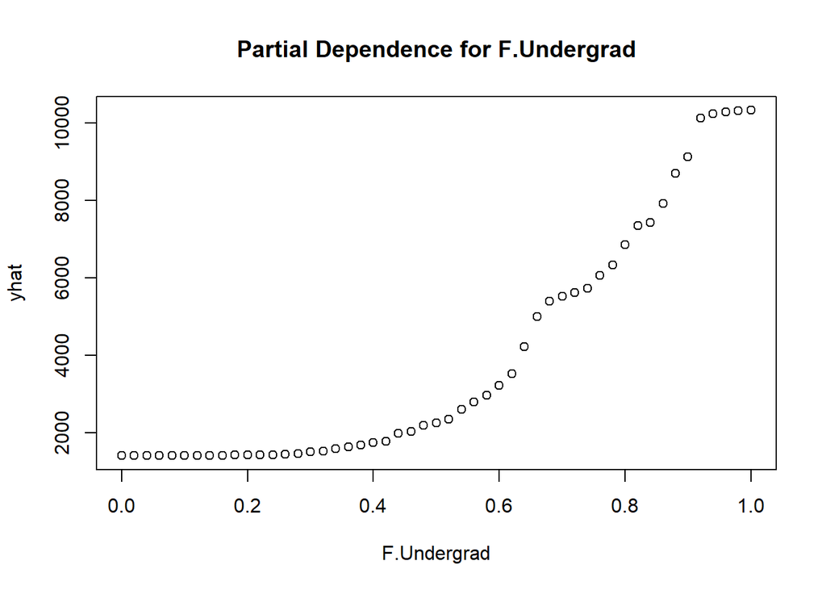

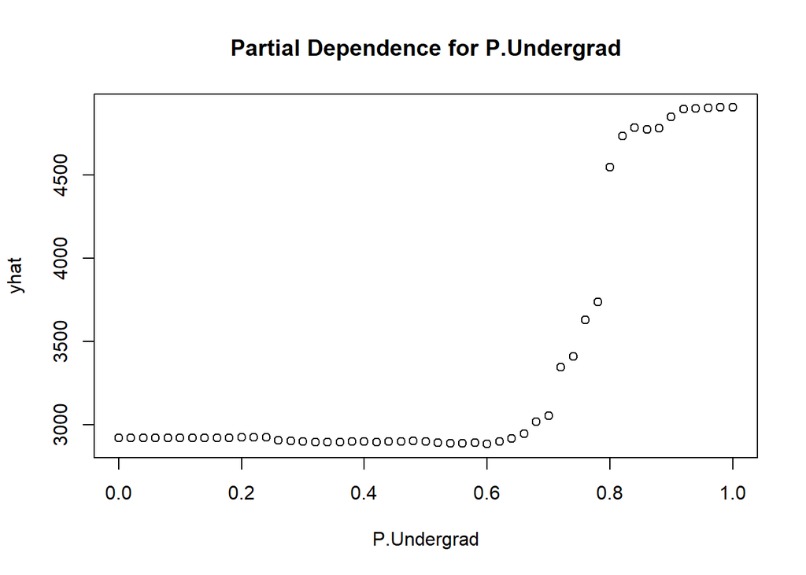

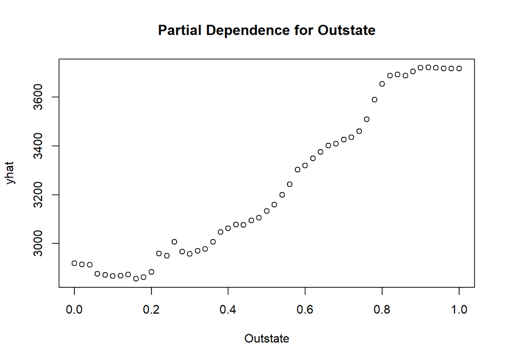

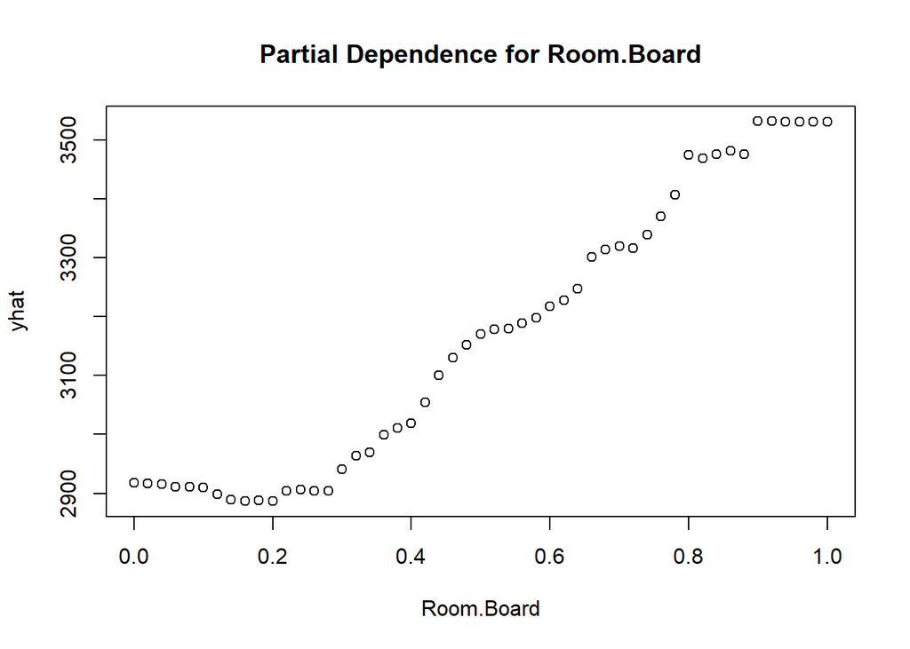

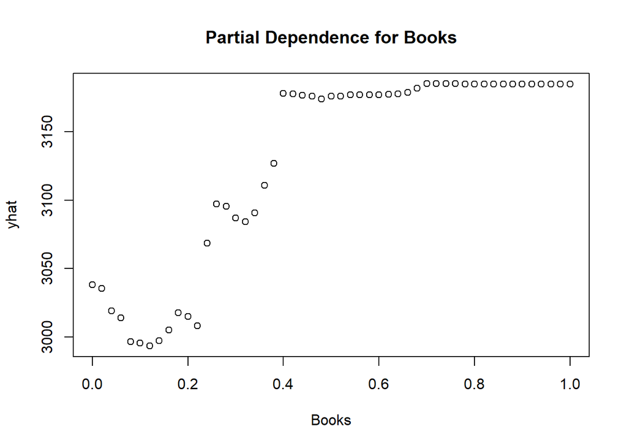

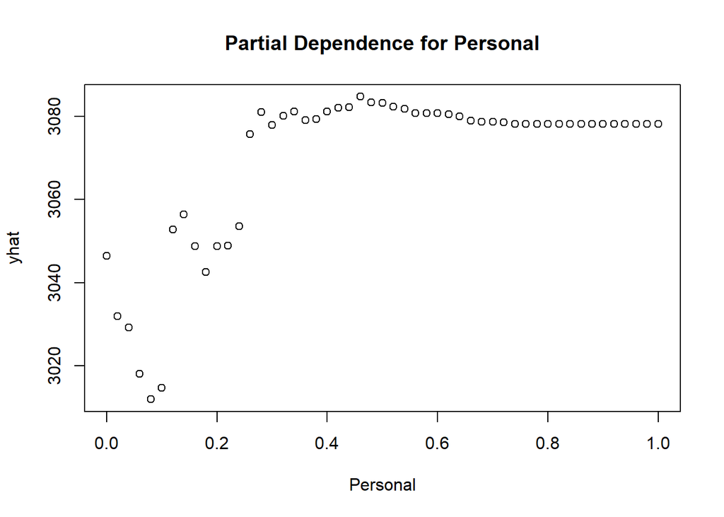

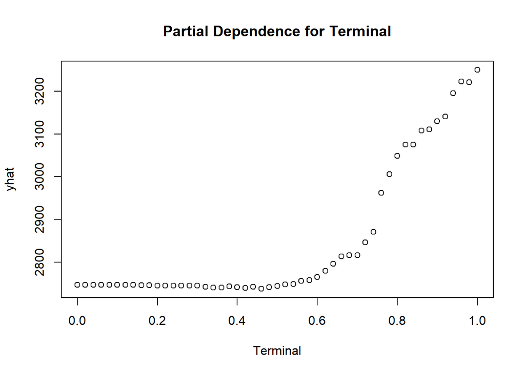

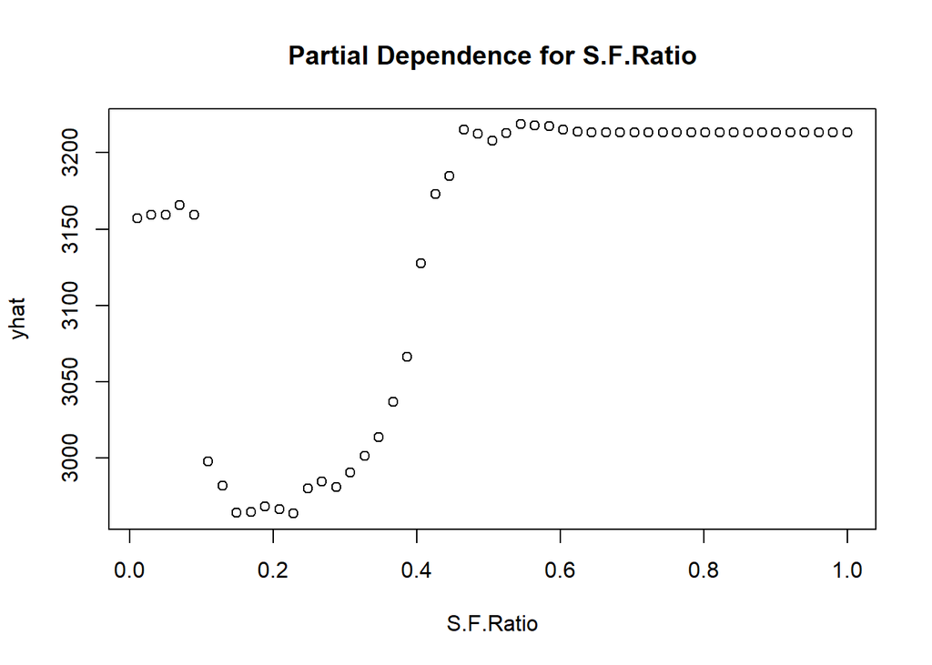

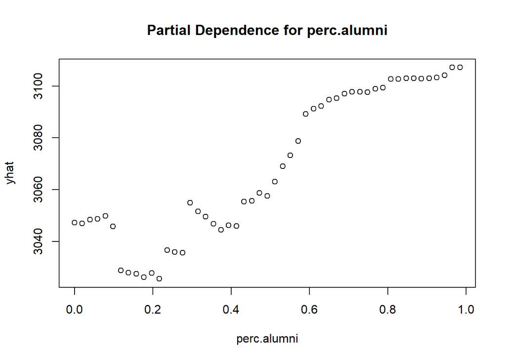

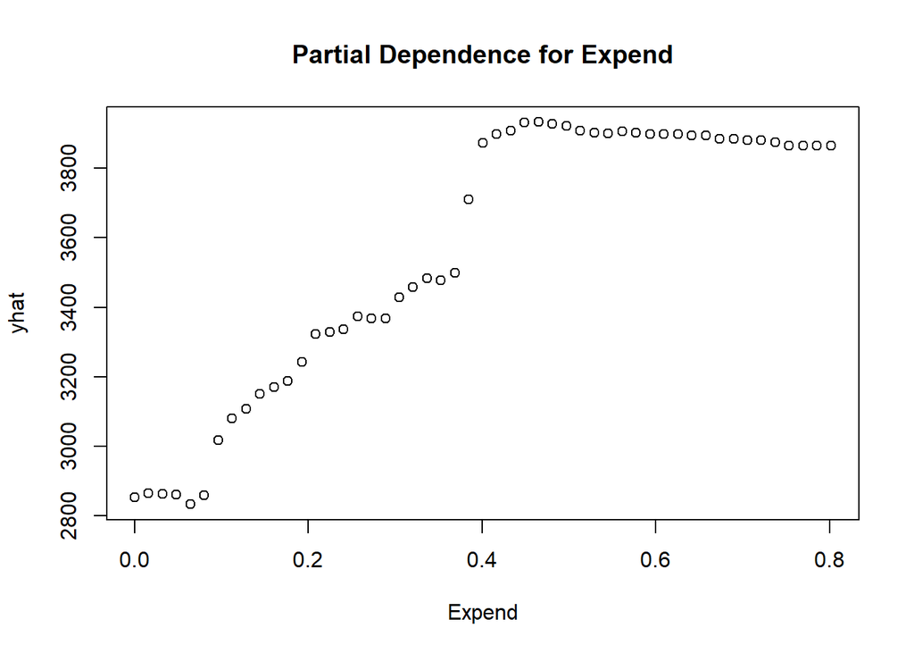

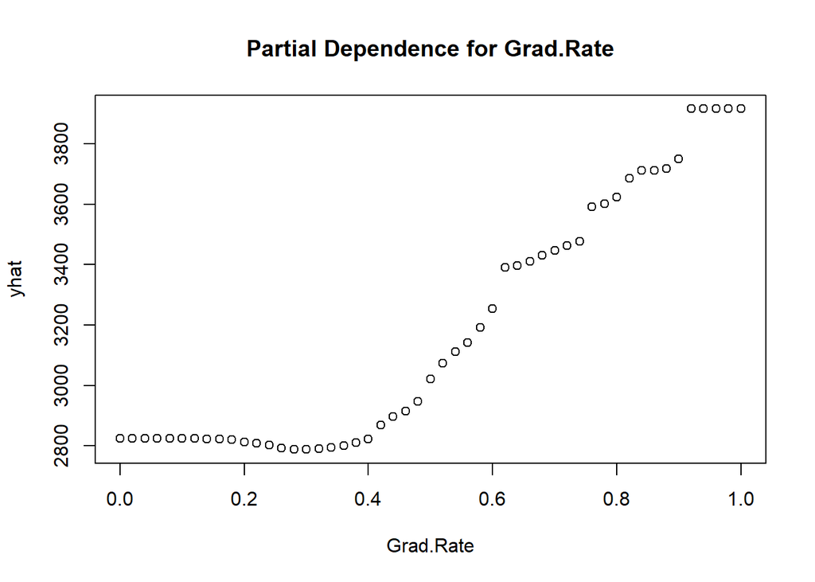

```r
# Partial dependence plot for F.Undergrad
for (pred in names) {
  pdp_obj <- partial(random_forest_1000, pred.var = pred, train = train_data)
  plot(pdp_obj, main = paste("Partial Dependence for", pred))
}
```

##### Most of the features show us that they have a non-linear relatiohship with the response variable.

##### These two points regarding the GLM and the Random forest, suggest that a GAM could be a very strong alternative due to non-linearity between the featuers and the response variable.

##### Now lets fit a GAM on a training set

```r
library(mgcv)
# Fit GAM model
gam_model <- gam(College$Apps[train_index]  ~ s(F.Undergrad, k=3) + s(P.Undergrad, k=3) +
                               Grad.Rate + Outstate +
                               Room.Board + s(Expend, k=3) +
                               s(Books, k=3) + s(Personal, k=3) +
                               s(S.F.Ratio, k=3) + s(perc.alumni, k=3) +
                               s(Top25perc, k=3) + s(Terminal, k=3),
                 family = poisson, data = train_data, select= TRUE)

summary(gam_model)
```

```
##
## Family: poisson
## Link function: log
##
## Formula:
## College$Apps[train_index] ~ s(F.Undergrad, k = 3) + s(P.Undergrad,
##     k = 3) + Grad.Rate + Outstate + Room.Board + s(Expend, k = 3) +
##     s(Books, k = 3) + s(Personal, k = 3) + s(S.F.Ratio, k = 3) +
##     s(perc.alumni, k = 3) + s(Top25perc, k = 3) + s(Terminal,
##     k = 3)
##
## Parametric coefficients:
##             Estimate Std. Error z value Pr(>|z|)
## (Intercept) 6.569381   0.004297 1528.76   <2e-16 ***
## Grad.Rate   1.037421   0.007355  141.04   <2e-16 ***
## Outstate    0.383205   0.007291   52.56   <2e-16 ***
## Room.Board  0.537761   0.006299   85.38   <2e-16 ***
## ---
## Signif. codes:  0 '***' 0.001 '**' 0.01 '*' 0.05 '.' 0.1 ' ' 1
##
## Approximate significance of smooth terms:
##                   edf Ref.df   Chi.sq p-value
## s(F.Undergrad) 1.9965      2 441509.2  <2e-16 ***
## s(P.Undergrad) 1.9821      2    992.8  <2e-16 ***
## s(Expend)      1.9914      2   1853.7  <2e-16 ***
## s(Books)       1.9957      2   1358.7  <2e-16 ***
## s(Personal)    1.9966      2   1988.3  <2e-16 ***
## s(S.F.Ratio)   1.9878      2   3599.0  <2e-16 ***
## s(perc.alumni) 1.9833      2    474.9  <2e-16 ***
## s(Top25perc)   1.9970      2   7404.2  <2e-16 ***
## s(Terminal)    0.9967      2    274.6  <2e-16 ***
## ---
## Signif. codes:  0 '***' 0.001 '**' 0.01 '*' 0.05 '.' 0.1 ' ' 1
##
## R-sq.(adj) =  0.825   Deviance explained =   90%
## UBRE = 342.49  Scale est. = 1         n = 619
```

##### And compare it to the glm

```r
AIC(glm, gam_model)
```

|  | df | AIC |
| --- | --- | --- |
| glm | 14.00000 | 226871.6 |
| gam_model | 20.92708 | 218353.6 |

##### I we can see an improvement with the GAM model, a lower AIC and higher degrees of freedom. Lets compare the RMSE to the random forest model.

```r
gam_preds_test <- predict(gam_model, test_data, type = "response")

rmse_gam_test <- sqrt(mean((College$Apps[-train_index] - gam_preds_test)^2))

rmse_gam_test
```

```
## [1] 1308.551
```

```r
gam_preds_train <- predict(gam_model, train_data, type = "response")

rmse_gam_train <- sqrt(mean((College$Apps[train_index] - gam_preds_train)^2))

rmse_gam_train
```

```
## [1] 1649.383
```

##### We can also see a slight improvement in RMSE compared to the random forest models.

## Plot for visualising smooth terms

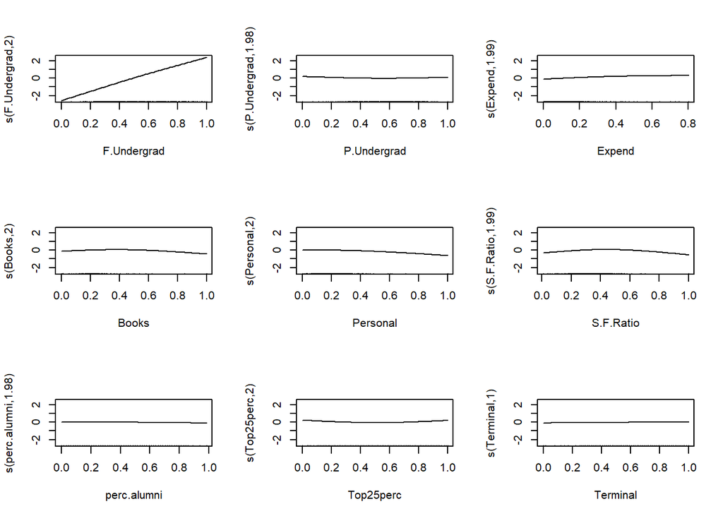

```r
plot(gam_model, pages = 1, shade = TRUE, seWithMean = TRUE)
```

## Comparing predictions of the GAM vs Random forest

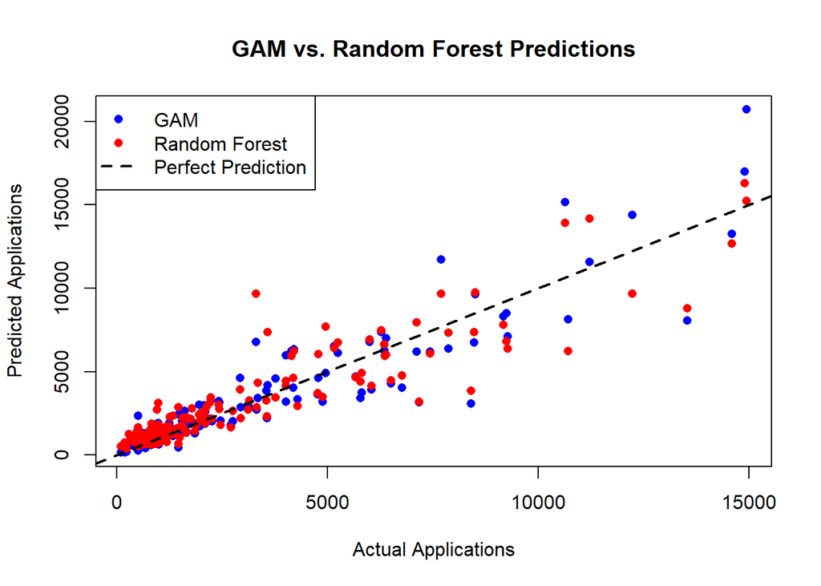

```r
plot(College$Apps[-train_index], gam_preds_test, col = "blue", pch = 16,
     main = "GAM vs. Random Forest Predictions",
     xlab = "Actual Applications", ylab = "Predicted Applications")
points(College$Apps[-train_index], predict(random_forest_1000, test_data), col = "red", pch = 16)

# Add a perfect prediction reference line
abline(0, 1, col = "black", lwd = 2, lty = 2)

legend("topleft", legend = c("GAM", "Random Forest", "Perfect Prediction"),
       col = c("blue", "red", "black"), pch = c(16, 16, NA), lty = c(NA, NA, 2), lwd = c(NA, NA, 2))
```